# Permutation Analysis - What to do when your data is weird

The vast majority of times, you can analyze data using a parametric test or model - these are analyses like ANOVAs, LMs, GLMs etc. In those models, they estimate a null distribution using sample parameters from your data, and then compare the observed data to that distribution. However, there are several cases where your data may not fit that mold. A common example is non-normally distributed data. I also use them when I am not able to conceptually think of a way to use a parametric test. Here, as an example, I will be assessing the connectivity between clusters from my CellPhoneDB data to see which clusters receive the most inputs, and send the most inputs.

Load in libraries

```r
library(igraph)
library(ggplot2)
library(MASS) # For MDS implementation
library(dplyr)
library(igraph)
library(readr)
library(tidyverse)
```

[https://github.com/ggraham4/multiome_poa/blob/main/Python/CellPhoneDb/Network/degs_analysis_relevant_interactions_03_03_2025_224407.](https://github.com/ggraham4/multiome_poa/blob/main/Python/CellPhoneDb/Network/degs_analysis_relevant_interactions_03_03_2025_224407.txt)txt

```r
example_data <- read_tsv('C:/Users/Gabe/Desktop/multiome_poa/Python/CellPhoneDb/Network/degs_analysis_relevant_interactions_03_03_2025_224407.txt')
```

We do some data wrangling because it’s in an inconvenient format

```r
example_data_filtered = example_data%>%
  dplyr::select(-c(1, 3:13)) #remove columns containing info IDC about

example_data_filtered_long = example_data_filtered%>%
  pivot_longer(cols = colnames(example_data_filtered[,-1]), values_to = 'signif', names_to = 'cluster_pair')%>%
  subset(signif == 1)
#pivot longer such that significance value is in one column, then subset to only significant interactions (signif = 1)

#split clusters into senders (before |) and receivers (after |)
example_data_filtered_long <- example_data_filtered_long %>%
  mutate(
    sender = sapply(strsplit(cluster_pair, "\\|"), `[`, 1),
    receiver = sapply(strsplit(cluster_pair, "\\|"), `[`, 2)
  )%>%
  subset(sender != '30' & sender !='15' & receiver != '30' & receiver!= '15')
#remove 30 and 15

example_data_filtered_long_grouped <- example_data_filtered_long%>%
  group_by(sender, receiver)%>%
  summarize(interactions =n())
#summarize the number of significant interactions
```

Make interaction matrix where rows are senders, columns are receivers, and the cell is the number of significant communications from the sender to the receiver

```r
# a square matrix 30 cols x 30 rows
matrix = matrix(NA, 30, 30)

#give columns and rows names
colnames(matrix) = c(0:14, 16:29,31)
rownames(matrix) = c(0:14, 16:29,31)

#give the data frame a shorter name cause it's too long
shortened_name = example_data_filtered_long_grouped

#here this for loop essentially says for i in columns and j and columns (which has the same names as the rows):
for(i in colnames(matrix)){
  for(j in colnames(matrix)){
    sender = which(colnames(matrix)==i) #find the col and row names of the matrix that correspond to the name
    reciever = which(rownames(matrix)==j)

    if(length(shortened_name$interactions[shortened_name$sender == i & shortened_name$receiver ==j])==0){ # if there are no interactions, set it to 0
      matrix[i,j]=0
    }
    else{ # otherwise, find the number of interactions that corresponds to the sender j and receiver i
      matrix[i,j] = shortened_name$interactions[shortened_name$sender ==i & shortened_name$receiver ==j]
    }

  }
}  ### here, the matrix is organized such that rows are senders and columns are receivers #this is the correct input for igraph directed
```

Transpose this such that rows are now receivers and columns are now senders

```r
transposed_mat <- t(matrix)
```

Visualize distributions of columns (senders) and rows (receivers).

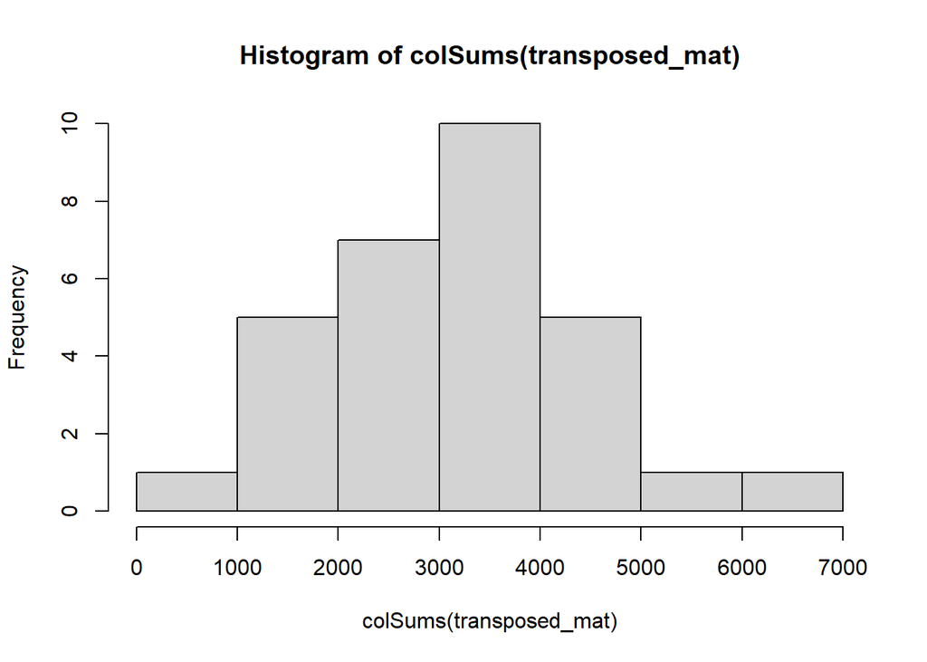

```r
hist(colSums(transposed_mat))
```

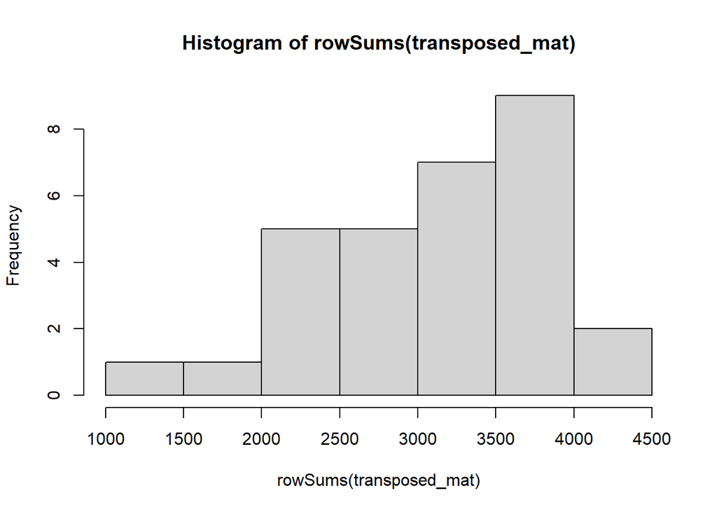

```r
hist(rowSums(transposed_mat))
```

Both are nearly normally distributed, but IDK how to analyze what I want to analyze using a parametric function so I’m going to use a permutation analysis

# How does a permutation analysis work?

A permutation analysis is a non-parametric test. Non-parametric tests are very useful because they have 0 assumptions about the data. There is no assumption of independence or normality or anything like that. They are very powerful tools. The one drawback is that they are more conservative than parametric tests because the assumptions you can make from normally distributed independent data are incredibly powerful.

What I want to ask in this analysis is: are any clusters significantly stronger senders (columns) or receivers (rows) than if their score just arose randomly from the data. To answer this question using a permutation analysis, what we can do is scramble the data around and then sample a column and ask what a “random” sender or receiver would look like. We repeat this many times (here, I do it 100K times) to generate a null distribution. We then ask what proportion of randomly permuted senders or receivers have a higher score than our real data. This is the permuted p-value and is incredibly robust.

Calculate the null distribution - this will take several minutes, it is 100k simulations

```r
sum_vals = sum(transposed_mat) #the sum of all values in the matrix
distribution_data = c() # initialize a list to add stuff into
for(i in 1:100000){
  sampled_values <-sample(matrix) #sample will select cells from the matrix in a random order
  fake_matrix <- matrix(sampled_values, 30, 30) #we then put those cells back into a matrix of the same size

  prop_perm <- sum(fake_matrix[,1])/sum_vals #we then ask what proportion of sends come from the scrambled first column from the fake matrix
  distribution_data <- append(distribution_data, prop_perm) # and add that value to the list
}
```

Visualize the null distribution

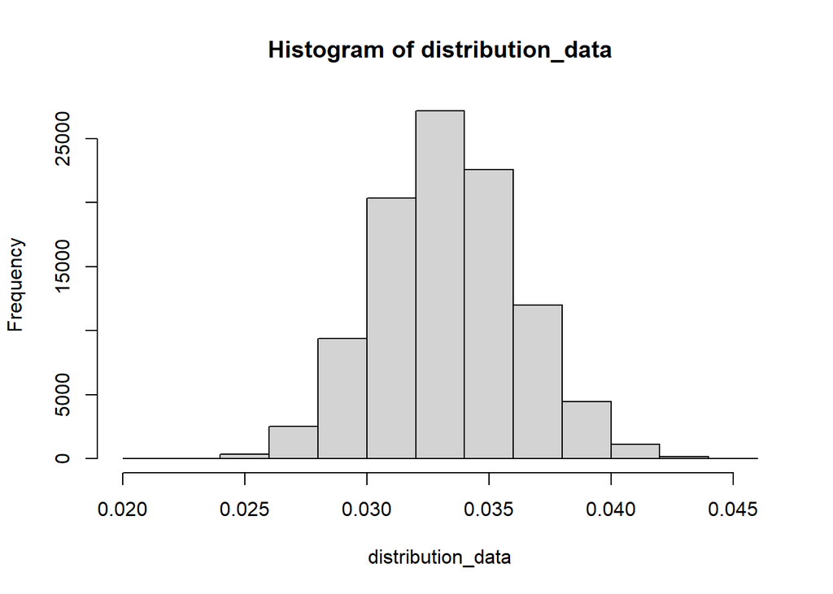

```r
hist(distribution_data)
```

Here, it looks incredibly close to a normal distribution which is pretty cool. The mean is more or less 0.033 which is what you would expect of a random sample of 1/30 columns.

Calculate our real sends

```r
# calculate the actual mean percent from each cluster
out_data <- data.frame() #initialize an empty data frame to add stuff into
for(i in colnames(transposed_mat)){ #the names of senders
  cluster_index = which(colnames(transposed_mat)==i) #find the column that corresponds to the name i
  prop_real_send <- sum(transposed_mat[,cluster_index])/sum(transposed_mat)
  #find the proportion of sends that come from that cluster

  newd = data.frame(cluster = i,
                    prop_real_send = prop_real_send) #add that to a data frame
  out_data <- rbind(newd, out_data) #and add to out data
}
out_data
```

```
##    cluster prop_real_send
## 1       31    0.038847936
## 2       29    0.021633304
## 3       28    0.034910717
## 4       27    0.047107535
## 5       26    0.015716777
## 6       25    0.037146800
## 7       24    0.032813720
## 8       23    0.022296639
## 9       22    0.021376529
## 10      21    0.033798025
## 11      20    0.046144629
## 12      19    0.045128227
## 13      18    0.036526261
## 14      17    0.053484117
```

[output cut: 16 more lines]

Calculate p-values

```r
perm_p_sends<- c() #initialize a list to add stuff into
for(i in out_data$cluster){ # for each cluster

  #Calculate the proportion of permuted sends larger than real sends
  perm_p <- sum(distribution_data>out_data$prop_real[out_data$cluster==i])/length(distribution_data)

  perm_p_sends <- append(perm_p_sends, perm_p) #add that calculation to the list
}
out_data$perm_p_send <- perm_p_sends #add the list to out_data
out_data
```

```
##    cluster prop_real_send perm_p_send
## 1       31    0.038847936     0.03124
## 2       29    0.021633304     0.99999
## 3       28    0.034910717     0.28761
## 4       27    0.047107535     0.00000
## 5       26    0.015716777     1.00000
## 6       25    0.037146800     0.09563
## 7       24    0.032813720     0.56300
## 8       23    0.022296639     0.99999
## 9       22    0.021376529     0.99999
## 10      21    0.033798025     0.42874
## 11      20    0.046144629     0.00000
## 12      19    0.045128227     0.00005
## 13      18    0.036526261     0.13477
## 14      17    0.053484117     0.00000
```

[output cut: 16 more lines]

Calculate real receptions

```r
out_data_rec <- data.frame()
for(i in rownames(transposed_mat)){
  cluster_index = which(rownames(transposed_mat)==i)

    #Calculate the proportion of permuted receptions larger than real receptions
  prop_real_rec <- sum(transposed_mat[cluster_index,])/sum(transposed_mat)

  newd = data.frame(cluster = i,
                    prop_real_rec = prop_real_rec)
  out_data_rec <- rbind(newd, out_data_rec)
}

out_data$prop_real_rec <- out_data_rec$prop_real_rec
out_data
```

```
##    cluster prop_real_send perm_p_send prop_real_rec
## 1       31    0.038847936     0.03124    0.03705051
## 2       29    0.021633304     0.99999    0.02519606
## 3       28    0.034910717     0.28761    0.02736795
## 4       27    0.047107535     0.00000    0.04168316
## 5       26    0.015716777     1.00000    0.02221105
## 6       25    0.037146800     0.09563    0.03373383
## 7       24    0.032813720     0.56300    0.03623739
## 8       23    0.022296639     0.99999    0.03506050
## 9       22    0.021376529     0.99999    0.02668321
## 10      21    0.033798025     0.42874    0.02997850
## 11      20    0.046144629     0.00000    0.03763895
## 12      19    0.045128227     0.00005    0.03662255
## 13      18    0.036526261     0.13477    0.03922240
## 14      17    0.053484117     0.00000    0.04048488
```

[output cut: 16 more lines]

Compute reception p-values in the same way

```r
perm_p_recs<- c()
for(i in out_data$cluster){

  perm_p <- sum(distribution_data>out_data$prop_real_rec[out_data$cluster==i])/length(distribution_data)

  perm_p_recs <- append(perm_p_recs, perm_p)
}
out_data$perm_p_rec <- perm_p_recs

#label data if they are significant senders or receivers
out_data$sig_rec <- ifelse(out_data$perm_p_rec<0.05, '*', NA)
out_data$sig_send <- ifelse(out_data$perm_p_send<0.05, '*', NA)

out_data
```

```
##    cluster prop_real_send perm_p_send prop_real_rec perm_p_rec sig_rec sig_send
## 1       31    0.038847936     0.03124    0.03705051    0.10111    <NA>        *
## 2       29    0.021633304     0.99999    0.02519606    0.99858    <NA>     <NA>
## 3       28    0.034910717     0.28761    0.02736795    0.98387    <NA>     <NA>
## 4       27    0.047107535     0.00000    0.04168316    0.00256       *        *
## 5       26    0.015716777     1.00000    0.02221105    0.99999    <NA>     <NA>
## 6       25    0.037146800     0.09563    0.03373383    0.43738    <NA>     <NA>
## 7       24    0.032813720     0.56300    0.03623739    0.15674    <NA>     <NA>
## 8       23    0.022296639     0.99999    0.03506050    0.27040    <NA>     <NA>
## 9       22    0.021376529     0.99999    0.02668321    0.99178    <NA>     <NA>
## 10      21    0.033798025     0.42874    0.02997850    0.87896    <NA>     <NA>
## 11      20    0.046144629     0.00000    0.03763895    0.07182    <NA>        *
## 12      19    0.045128227     0.00005    0.03662255    0.12830    <NA>        *
## 13      18    0.036526261     0.13477    0.03922240    0.02385       *     <NA>
## 14      17    0.053484117     0.00000    0.04048488    0.00815       *        *
```

[output cut: 16 more lines]

If you look closely at this data, clusters 0, 1, and 11 have permuted p values for reception of 0. This means that out of 100,000 shufflings of the data, the real data is still the strongest receivers, which is an incredibly powerful statement to make. Similarly, several clusters have sending p-values of 0. Using the 0.05 threshold, it’s clear many of our clusters are not just random noise and this is incredibly interesting.

# Visualize significant senders and receivers using a directed network graph

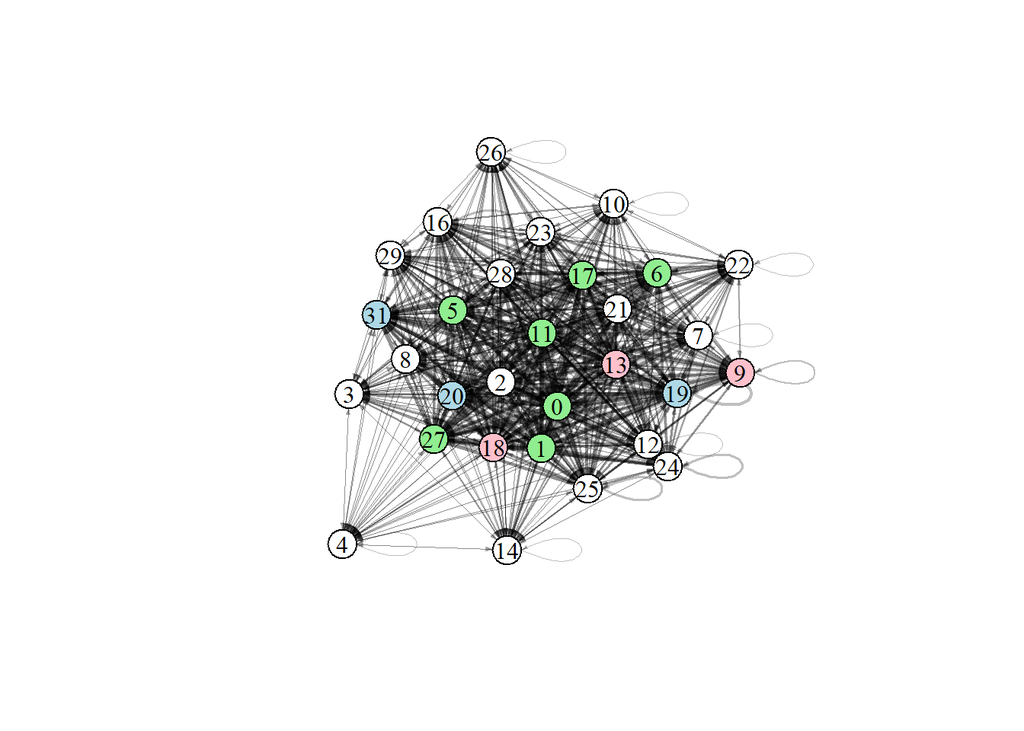

```r
### this code is really weird cause I copy and pased it from when I visualized only the strongest connections, so the names dont make a lot of sense
matrix_subset <- matrix
signif_interaction_value = max(matrix_subset)*0 #no subsetting

matrix_subset_threshold <- ifelse(matrix_subset<signif_interaction_value, 0, matrix_subset)
### transpose such that columns are now senders and rows are now receivers ## this is the format igraph wants

#compute a graph
g <- graph_from_adjacency_matrix((matrix_subset_threshold), mode = "directed", weighted = TRUE)

# Set edge width based on the number of interactions
E(g)$width <- ((E(g)$weight)-min((E(g)$weight)))/((max(E(g)$weight))-min(E(g)$weight))*4

#remove 0s
Isolated = which(degree(g)==0)
g2 = delete_vertices(g, Isolated)

#doing this stuff for visualization
out_data$cluster <- as.character(out_data$cluster)
cluster_colors <- rep("white", length(V(g2)))
names(cluster_colors) <- V(g2)$name

# Assign colors based on conditions
red_clusters <- as.character(out_data$cluster[!is.na(out_data$sig_rec) & is.na(out_data$sig_send)]) #significant receievers

blue_clusters <- as.character(out_data$cluster[is.na(out_data$sig_rec) & !is.na(out_data$sig_send)]) #significant senders

green_clusters <- as.character(out_data$cluster[!is.na(out_data$sig_rec) & !is.na(out_data$sig_send)]) # significant both

# Update colors for each group
cluster_colors[names(cluster_colors) %in% red_clusters] <- "pink" #receive
cluster_colors[names(cluster_colors) %in% blue_clusters] <- "lightblue" #send
cluster_colors[names(cluster_colors) %in% green_clusters] <- "lightgreen" #both

# Assign to vertex colors
V(g2)$color <- cluster_colors

# Plot the graph
set.seed(7)
plot(g2,
     edge.color = adjustcolor("black", alpha.f = .25),
     edge.arrow.size =.2,
     edge.alpha = 0.95,
     edge.curved = 0,
     vertex.label.color='black')
```